# 3D-omics web database mock data

```r
library(tidyverse)
library(ape)
library(rairtable)
library(distillR)
library(rmarkdown)
```

```r
selected_cryosection="G121eI104C"
```

## Load data

### Sample metadata

```r
sample_metadata <- airtable("4-MSE-Info", "appKakM1bnKSekwuW") %>% #get base ID from Airtable browser URL
  read_airtable(., fields = c("ID","LabBatch_text","IntestinalSection","SampleType","Xcoord","Ycoord","size","cryosection_text","buffer_text","Collection_Success","UsedCycles"), id_to_col = TRUE) %>% #get 3 columns from MAGs table
  filter(cryosection_text == selected_cryosection) %>%
  rename(batch=LabBatch_text,microsample=ID,section=IntestinalSection,type=SampleType,cryosection=cryosection_text,buffer=buffer_text,collection=Collection_Success,cycles=UsedCycles) %>%
  select(microsample,section,type,batch,cryosection,buffer,Xcoord,Ycoord,size,collection,cycles) %>%
  unnest(c(section, Xcoord, Ycoord, size, collection, cycles)) %>%
  arrange(microsample)
```

### Count data

```r
read_counts <- read_tsv("data/REF0015-g_mg_hybrid-0.95.genome.count.tsv.gz") %>%
  rename(genome = 1) %>%
  pivot_longer(!genome, names_to = "data", values_to="counts") %>%
  mutate(sample = substr(data, 1, 7)) %>%
  group_by(genome,sample) %>%
  summarise(counts=sum(counts), .groups="drop") %>%
  filter(sample %in% sample_metadata$microsample) %>%
  pivot_wider(names_from="sample", values_from="counts")
```

#### Base hit table

This is the document containing the number of nucleotide bases have been covered by at least one read in each sample and MAG. This information is used to calculate MAG coverage values.

```r
basehits <- read_tsv("data/REF0015-g_mg_hybrid-0.95.genome.covered_bases.tsv.gz") %>%
  rename(genome = 1) %>%
  pivot_longer(!genome, names_to = "data", values_to="counts") %>%
  mutate(sample = substr(data, 1, 7)) %>%
  group_by(genome,sample) %>%
  summarise(counts=sum(counts), .groups="drop") %>%
  filter(sample %in% sample_metadata$microsample) %>%
  pivot_wider(names_from="sample", values_from="counts")
```

#### Genome metadata

Relevant metadata of genomes is fetched from 2-3 files and merged into one genome metadata object for downstream analyses.

##### Taxonomy

This is the raw taxonomy table generated by GTDBtk, which is simplified for downstream analyses.

```r
genome_taxonomy <- read_tsv("data/gtdbtk.summary.tsv") %>%
  rename(genome = user_genome) %>%
  mutate(genome = str_replace_all(genome,"\\.fa", "")) %>%
  separate(classification, c("domain","phylum","class","order","family","genus","species"),  sep =";") %>%
  select(genome,domain,phylum,class,order,family,genus,species) %>%
  filter(genome %in% read_counts$genome) %>%
  arrange(match(genome, read_counts$genome))
```

##### Genome quality

Quality properties of the genomes.

```r
genome_quality <- read_csv("data/genomeInfo.csv") %>%
  rename(genome = 1) %>%
  mutate(genome = str_replace_all(genome,"\\.fa", "")) %>%
  filter(genome %in% read_counts$genome) %>%
  arrange(match(genome, read_counts$genome))
```

##### Merged metadata object

Merge taxonomy, length and quality information

```r
genome_metadata <- genome_taxonomy %>%
  left_join(genome_quality,by=join_by(genome==genome)) #join quality
```

#### Genome tree

This is the raw tree generated by GTDBtk, which needs to be pruned to obtain the phylogenetic tree of the genomes. Note that the archaeal tree is only generated if any archaeans are detected among the genomes.

```r
genome_tree <- read.tree("data/gtdbtk.backbone.bac120.classify.tree")
genome_tree$tip.label <- str_replace_all(genome_tree$tip.label,"'", "") #remove single quotes in MAG names
genome_tree <- keep.tip(genome_tree, tip=read_counts$genome) # keep only MAG tips
```

#### MAG functional annotations

This is the raw annotation table generated by DRAM, which is used to generate GIFT data using distillR.

```r
genome_annotations <- read_tsv("data/genome_annotations.tsv.xz") %>%
  rename(gene=1,genome=2) %>%
  filter(genome %in% read_counts$genome)
```

## Filter and normalise data

Raw data needs to be filtered and normalised to make it useful for downstream analyses.

### Generate coverage table

By dividing the number of base hits by the length of each genome, coverage values can be calculated.

```r
genome_coverage <- basehits %>%
  mutate(across(where(is.numeric), ~ ./genome_metadata$length))
```

### Coverage filtering

Genomes that have less than 30% of their length covered by reads are turned into zeros to account for the random allocation of reads across genomes due to mapping heuristics.

```r
min_coverage=0.3
read_counts_filt <- genome_coverage %>%
  mutate(across(where(is.numeric), ~ ifelse(. > min_coverage, 1, 0))) %>%
  mutate(across(-1, ~ . * read_counts[[cur_column()]]))
```

### Generate genome count table

After filtering the low-coverage reads, read counts are transformed into genome counts using genome-length and read-length information.

```r
readlength=150 #change if sequencing read length is different
genome_counts_filt <- read_counts_filt %>%
  mutate(across(where(is.numeric), ~ . / (genome_metadata$length / readlength) ))

genome_counts <- read_counts %>%
  mutate(across(where(is.numeric), ~ . / (genome_metadata$length / readlength) ))
```

### Distil functional annotations

Raw functional annotations are distilled into genome-inferred functional traits to generate biologically more meaningful functional traits for downstream analyses.

```r
genome_gifts <- distill(genome_annotations,GIFT_db,genomecol=2,annotcol=c(9,10,19))
```

## Tables

### Microsample metadata

```r
sample_metadata %>%
  select(-collection) %>%
  paged_table()
```

| microsample | section | type | batch | cryosection | buffer | Xcoord | Ycoord | size | cycles |
| --- | --- | --- | --- | --- | --- | --- | --- | --- | --- |
| M301570 | Caecum right | Positive | MSEB0015 | G121eI104C | B11 | 10622.70 | 46523.97 | 4976 | 15 |
| M301571 | Caecum right | Positive | MSEB0015 | G121eI104C | B11 | 11163.69 | 46464.93 | 4976 | 15 |
| M301572 | Caecum right | Positive | MSEB0015 | G121eI104C | B11 | 11574.92 | 46452.87 | 4976 | 15 |
| M301573 | Caecum right | Positive | MSEB0015 | G121eI104C | B11 | 12078.10 | 46438.84 | 4976 | 15 |
| M301576 | Caecum right | Positive | MSEB0015 | G121eI104C | B11 | 13566.04 | 46499.60 | 4976 | 15 |
| M301577 | Caecum right | Positive | MSEB0015 | G121eI104C | B11 | 13976.24 | 46491.45 | 4976 | 15 |
| M301578 | Caecum right | Positive | MSEB0015 | G121eI104C | B11 | 12406.36 | 44865.24 | 5140 | 15 |
| M301579 | Caecum right | Positive | MSEB0015 | G121eI104C | B11 | 12373.87 | 45172.40 | 5140 | 15 |
| M301580 | Caecum right | Positive | MSEB0015 | G121eI104C | B11 | 12519.61 | 45558.77 | 5140 | 15 |
| M301582 | Caecum right | Positive | MSEB0015 | G121eI104C | B11 | 12463.19 | 46128.54 | 5140 | 15 |

[output cut: 44 more lines]

```r
sample_metadata %>%
  select(-collection) %>%
  write_tsv("tables/microsample_metadata.tsv")
```

### Genome metadata

```r
genome_metadata %>%
  paged_table()
```

| genome | domain | phylum | class | order | family | genus | species | completeness | contamination | length | N50 |
| --- | --- | --- | --- | --- | --- | --- | --- | --- | --- | --- | --- |
| D300418:bin_000001 | d__Bacteria | p__Bacillota_A | c__Clostridia | o__Oscillospirales | f__Ruminococcaceae | g__Faeciplasma | s__Faeciplasma gallinarum | 99.49 | 0.17 | 1791036 | 79551 |
| D300418:bin_000013 | d__Bacteria | p__Bacillota_A | c__Clostridia | o__Oscillospirales | f__Acutalibacteraceae | g__Fimivicinus | s__Fimivicinus intestinavium | 81.41 | 1.94 | 2332804 | 6434 |
| D300428:bin_000008 | d__Bacteria | p__Bacillota_A | c__Clostridia | o__Christensenellales | f__Borkfalkiaceae | g__Coproplasma | s__Coproplasma excrementigallinarum | 82.32 | 3.54 | 1922776 | 10687 |
| D300430:bin_000010 | d__Bacteria | p__Bacillota_A | c__Clostridia | o__Oscillospirales | f__Oscillospiraceae | g__Intestinimonas | s__Intestinimonas timonensis | 83.60 | 7.68 | 3001106 | 17315 |
| D300432:bin_000001 | d__Bacteria | p__Bacillota_A | c__Clostridia | o__Lachnospirales | f__Anaerotignaceae | g__Fimicola | s__Fimicola sp944379995 | 95.93 | 0.97 | 2795297 | 79630 |
| D300435:bin_000001 | d__Bacteria | p__Bacillota_A | c__Clostridia | o__Lachnospirales | f__Anaerotignaceae | g__Anaerotignum | s__Anaerotignum merdipullorum | 99.64 | 0.51 | 2545646 | 41671 |
| D300442:bin_000001 | d__Bacteria | p__Bacillota_A | c__Clostridia | o__Lachnospirales | f__CAG-274 | g__Tyzzerella | s__Tyzzerella sp944383305 | 95.41 | 0.23 | 2386391 | 19562 |
| D300442:bin_000015 | d__Bacteria | p__Bacillota_A | c__Clostridia | o__Oscillospirales | f__Butyricicoccaceae | g__Agathobaculum | s__Agathobaculum merdipullorum | 78.79 | 7.07 | 2858118 | 11246 |
| D300443:bin_000002 | d__Bacteria | p__Bacillota | c__Bacilli | o__Erysipelotrichales | f__Erysipelotrichaceae | g__Clostridium_AQ | s__Clostridium_AQ sp900552125 | 100.00 | 1.11 | 2697713 | 51850 |
| D300443:bin_000003 | d__Bacteria | p__Bacillota_A | c__Clostridia | o__Christensenellales | f__Borkfalkiaceae | g__Scatosoma | s__Scatosoma sp900555925 | 92.99 | 0.64 | 3351616 | 43028 |

[output cut: 213 more lines]

```r
genome_metadata %>%
  write_tsv("tables/genome_metadata.tsv")
```

### Genome counts per microsample

```r
genome_counts %>%
  paged_table()
```

| genome | M301570 | M301571 | M301572 | M301573 | M301576 | M301577 | M301578 | M301579 | M301580 | M301582 | M301583 | M301584 | M301587 | M301588 | M301589 | M301591 | M301592 | M301593 | M301594 | M301595 | M301597 | M301598 | M301599 | M301601 | M301602 | M301603 | M301604 | M301606 | M301608 | … |
| --- | --- | --- | --- | --- | --- | --- | --- | --- | --- | --- | --- | --- | --- | --- | --- | --- | --- | --- | --- | --- | --- | --- | --- | --- | --- | --- | --- | --- | --- | --- |
| D300418:bin_000001 | 1.772996e-01 | 1.613870e-01 | 2.072823e-01 | 2.175836e-01 | 2.085385e-01 | 2.123910e-01 | 2.034297e-01 | 2.031785e-01 | 2.224411e-01 | 2.039322e-01 | 1.340007e-01 | 1.782209e-01 | 1.994935e-01 | 2.302299e-01 | 2.006660e-01 | 1.860097e-01 | 0.000000e+00 | 1.916209e-01 | 2.596263e-01 | 2.227761e-01 | 1.571995e-01 | 2.338311e-01 | 1.675846e-01 | 0.000000e+00 | 2.464775e-01 | 1.892759e-01 | 2.600450e-01 | 2.031785e-01 | 3.027577e-01 | … |
| D300418:bin_000013 | 1.691098e-02 | 1.138115e-02 | 2.391971e-02 | 2.211930e-02 | 1.768258e-02 | 2.006169e-02 | 1.118825e-02 | 1.215276e-02 | 2.211930e-02 | 1.620368e-02 | 9.452144e-03 | 1.215276e-02 | 2.109050e-02 | 1.916149e-02 | 1.125255e-02 | 2.109050e-02 | 0.000000e+00 | 1.324586e-02 | 1.768258e-02 | 1.376026e-02 | 1.041665e-02 | 1.787548e-02 | 7.265934e-03 | 0.000000e+00 | 2.289091e-02 | 2.006169e-02 | 3.227875e-02 | 1.286006e-02 | 2.353391e-02 | … |
| D300428:bin_000008 | 5.234619e-02 | 5.023986e-02 | 6.217573e-02 | 6.833869e-02 | 5.008384e-02 | 7.099111e-02 | 6.404802e-02 | 6.030344e-02 | 5.562270e-02 | 5.101998e-02 | 6.279983e-02 | 4.727540e-02 | 5.437451e-02 | 6.748056e-02 | 6.451610e-02 | 6.857273e-02 | 0.000000e+00 | 5.944530e-02 | 7.980649e-02 | 6.365796e-02 | 4.571515e-02 | 6.779261e-02 | 4.095641e-02 | 0.000000e+00 | 8.635951e-02 | 4.969378e-02 | 5.874319e-02 | 6.186368e-02 | 8.682759e-02 | … |
| D300430:bin_000010 | 6.369152e+00 | 6.858322e+00 | 1.004430e+01 | 6.974979e+00 | 9.556777e+00 | 9.543582e+00 | 5.804110e+00 | 7.215090e+00 | 6.556633e+00 | 1.136566e+01 | 5.370420e+00 | 5.008204e+00 | 9.207605e+00 | 7.743995e+00 | 8.171537e+00 | 5.938311e+00 | 5.697899e-03 | 6.514898e+00 | 1.267648e+01 | 7.738947e+00 | 4.485296e+00 | 5.963901e+00 | 5.105618e+00 | 3.298784e-03 | 6.863220e+00 | 8.052731e+00 | 7.869099e+00 | 7.059497e+00 | 1.047669e+01 | … |
| D300432:bin_000001 | 1.028692e-01 | 8.199486e-02 | 1.221337e-01 | 9.519561e-02 | 9.997149e-02 | 9.374675e-02 | 1.215971e-01 | 1.108648e-01 | 1.365150e-01 | 9.471265e-02 | 8.789764e-02 | 1.169285e-01 | 1.066792e-01 | 1.208458e-01 | 1.314172e-01 | 1.043181e-01 | 0.000000e+00 | 9.256619e-02 | 1.417738e-01 | 1.154260e-01 | 1.475156e-01 | 1.323831e-01 | 7.737997e-02 | 0.000000e+00 | 1.454228e-01 | 1.174115e-01 | 1.259437e-01 | 1.152114e-01 | 1.398957e-01 | … |
| D300435:bin_000001 | 1.694069e+00 | 1.952334e+00 | 2.299986e+00 | 2.669912e+00 | 2.478114e+00 | 2.595078e+00 | 2.201759e+00 | 1.276179e+00 | 3.296570e+00 | 2.150731e+00 | 1.861944e+00 | 2.495850e+00 | 2.429914e+00 | 2.641098e+00 | 2.556718e+00 | 2.718229e+00 | 1.649876e-03 | 2.730662e+00 | 3.010729e+00 | 2.622124e+00 | 1.499973e+00 | 2.320668e+00 | 2.044196e+00 | 1.060635e-03 | 3.686707e+00 | 3.132466e+00 | 3.568505e+00 | 2.724240e+00 | 4.262572e+00 | … |
| D300442:bin_000001 | 0.000000e+00 | 0.000000e+00 | 0.000000e+00 | 1.257128e-04 | 0.000000e+00 | 0.000000e+00 | 2.514257e-04 | 0.000000e+00 | 0.000000e+00 | 0.000000e+00 | 0.000000e+00 | 0.000000e+00 | 1.005703e-03 | 1.885693e-04 | 0.000000e+00 | 0.000000e+00 | 0.000000e+00 | 0.000000e+00 | 0.000000e+00 | 0.000000e+00 | 4.399950e-04 | 0.000000e+00 | 0.000000e+00 | 0.000000e+00 | 0.000000e+00 | 0.000000e+00 | 0.000000e+00 | 0.000000e+00 | 0.000000e+00 | … |
| D300442:bin_000015 | 1.354484e+01 | 8.104389e+00 | 1.353749e+01 | 1.468974e+01 | 1.250318e+01 | 9.152509e+00 | 1.700173e+01 | 1.558561e+01 | 1.466943e+01 | 8.511440e+00 | 8.965148e+00 | 1.822220e+01 | 1.258589e+01 | 1.238871e+01 | 2.909313e+01 | 1.406719e+01 | 9.446776e-03 | 1.799170e+01 | 1.487080e+01 | 1.144424e+01 | 1.182684e+01 | 1.747396e+01 | 9.756473e+00 | 4.093603e-03 | 1.731195e+01 | 1.252758e+01 | 1.275750e+01 | 9.523872e+00 | 1.311265e+01 | … |
| D300443:bin_000002 | 2.609989e-01 | 4.071226e-01 | 5.678699e-01 | 2.609989e-01 | 2.081207e-01 | 2.581075e-01 | 3.325595e-01 | 2.571067e-01 | 2.205757e-01 | 5.323954e-01 | 1.414531e-01 | 2.398698e-01 | 2.811270e-01 | 2.342540e-01 | 3.732606e-01 | 3.590819e-01 | 1.779285e-03 | 1.977230e-01 | 1.174884e-01 | 2.886890e-01 | 2.367005e-01 | 2.728422e-01 | 2.607208e-01 | 0.000000e+00 | 5.194956e-01 | 3.640306e-01 | 2.392582e-01 | 2.290273e-01 | 2.290829e-01 | … |
| D300443:bin_000003 | 1.088582e+01 | 8.196658e+00 | 1.030276e+01 | 1.123715e+01 | 1.099341e+01 | 1.126136e+01 | 1.099784e+01 | 1.272434e+01 | 1.211962e+01 | 1.231439e+01 | 1.173540e+01 | 1.143845e+01 | 1.106820e+01 | 1.195541e+01 | 1.411164e+01 | 9.411967e+00 | 8.279588e-03 | 1.057809e+01 | 1.673153e+01 | 1.468150e+01 | 6.493345e+00 | 1.296534e+01 | 9.755906e+00 | 4.699226e-03 | 1.380104e+01 | 1.268661e+01 | 1.482176e+01 | 1.210476e+01 | 1.478524e+01 | … |

[output cut: 213 more lines]

```r
genome_counts %>%
  write_tsv("tables/genome_counts.tsv")
```

## Visualisations

### Genomes per microsample

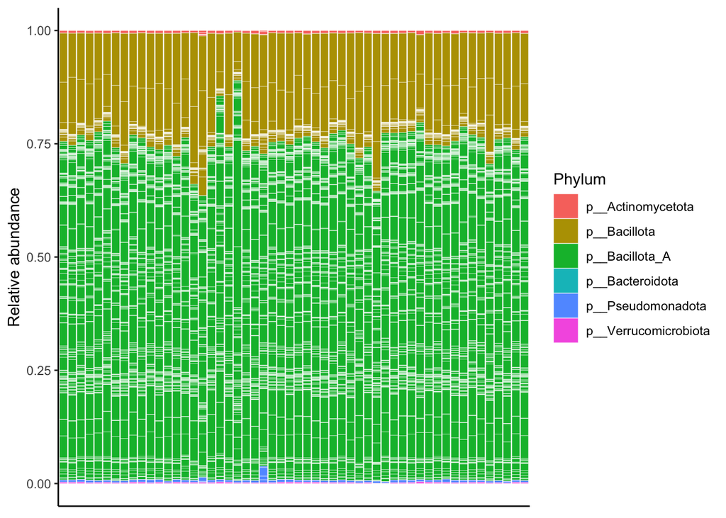

```r
genome_counts %>%
  mutate_at(vars(-genome),~./sum(.)) %>% #apply TSS normalisation
  pivot_longer(-genome, names_to = "microsample", values_to = "count") %>% #reduce to minimum number of columns
  left_join(., genome_metadata, by = join_by(genome == genome)) %>% #append genome metadata
  left_join(., sample_metadata, by = join_by(microsample == microsample)) %>% #append sample metadata
  filter(count > 0) %>% #filter 0 counts
  ggplot(., aes(x=microsample,y=count, fill=phylum, group=phylum)) + #grouping enables keeping the same sorting of taxonomic units
    geom_bar(stat="identity", colour="white", linewidth=0.1) + #plot stacked bars with white borders
    #scale_fill_manual(values=phylum_colors) +
    guides(fill = guide_legend(ncol = 1)) +
    theme(
          axis.title.x = element_blank(),
          panel.background = element_blank(),
          panel.border = element_blank(),
          panel.grid.major = element_blank(),
          panel.grid.minor = element_blank(),
          strip.background = element_rect(fill = "white"),
    strip.text = element_text(size = 12, lineheight = 0.6),
    strip.placement = "outside",
    axis.text.x = element_blank(), axis.ticks.x = element_blank(),
          axis.line = element_line(linewidth = 0.5, linetype = "solid", colour = "black")) +
   labs(fill="Phylum",y = "Relative abundance",x="Samples")
```